# Day3

```python
import pandas as pd
import numpy as np
import seaborn as sns
import matplotlib.pyplot as plt
data = pd.read_csv('sample_data.csv')
data.info()
```

```
<class 'pandas.core.frame.DataFrame'>
RangeIndex: 500 entries, 0 to 499
Data columns (total 11 columns):
 #   Column            Non-Null Count  Dtype
---  ------            --------------  -----
 0   id                500 non-null    int64
 1   sex               500 non-null    object
 2   is_employed       435 non-null    object
 3   income            493 non-null    float64
 4   marital_status    500 non-null    object
 5   health_insurance  500 non-null    bool
 6   housing_type      466 non-null    object
 7   recent_move       466 non-null    object
 8   num_vehicles      466 non-null    float64
 9   age               500 non-null    float64
 10  state_of_res      500 non-null    object
dtypes: bool(1), float64(3), int64(1), object(6)
memory usage: 39.7+ KB
```

```python
توضیح ستون‌ها:
id: شناسه‌ی منحصربه‌فرد برای هر فرد. این ستون به منظور شناسایی هر رکورد در داده استفاده می‌شود.

sex: جنسیت افراد (F = زن، M = مرد).

is_employed: وضعیت شغلی فرد (True = شاغل، False = بیکار).

income: میزان درآمد فرد (به احتمال زیاد سالانه و به دلار).

marital_status: وضعیت تأهل (مانند متأهل، مجرد، یا هر وضعیت دیگر).

health_insurance: اینکه فرد بیمه‌ی درمانی دارد یا نه (True = دارد، False = ندارد).

housing_type: نوع مسکن فرد (مانند اجاره‌ای، صاحب‌خانه، یا سکونت بدون اجاره).

recent_move: آیا فرد به تازگی جابه‌جا شده است یا خیر (True = بله، False = خیر).

num_vehicles: تعداد وسایل نقلیه‌ای که فرد مالک آن‌هاست.

age: سن فرد.

state_of_res: ایالتی که فرد در آن زندگی می‌کند.

این داده‌ها نمایی از وضعیت اجتماعی، اقتصادی و دموگرافیک افراد ارائه می‌دهند. به عنوان مثال
چه تعداد افراد شاغل هستند و درآمد آن‌ها چگونه توزیع شده است.
وضعیت تأهل چگونه بر درآمد یا مالکیت وسایل نقلیه تأثیر می‌گذارد.
تأثیر سن و جنسیت بر جنبه‌هایی مانند درآمد، نوع مسکن و وضعیت شغلی.
```

```python
data.head()
```

|  | id | sex | is_employed | income | marital_status | health_insurance | housing_type | recent_move | num_vehicles | age | state_of_res |
| --- | --- | --- | --- | --- | --- | --- | --- | --- | --- | --- | --- |
| 0 | 2068 | F | False | 11300.0 | Married | True | Homeowner free and clear | False | 2.0 | 49.0 | Michigan |
| 1 | 2073 | F | False | 0.0 | Married | True | Rented | True | 3.0 | 40.0 | Florida |
| 2 | 2848 | M | True | 45000.0 | Never Married | False | Rented | True | 3.0 | 29.0 | Georgia |
| 3 | 5641 | M | True | 20000.0 | Never Married | False | Occupied with no rent | False | 0.0 | 22.0 | New Mexico |
| 4 | 6369 | F | True | 42000.0 | Never Married | True | Rented | True | 1.0 | 31.0 | Florida |

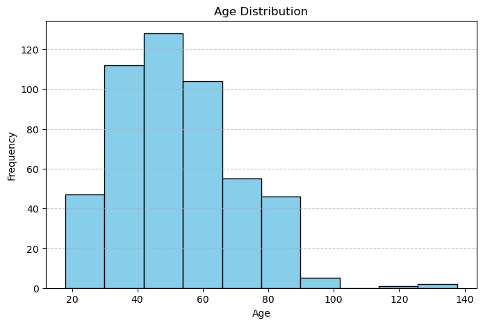

```python
plt.figure(figsize=(8, 5))
plt.hist(data['age'].dropna(), bins=10, color='skyblue', edgecolor='black')
plt.title('Age Distribution')
plt.xlabel('Age')
plt.ylabel('Frequency')
plt.grid(axis='y', linestyle='--', alpha=0.7)
plt.show()
```

2. ستونی (Bar Chart): تعداد افراد در هر وضعیت تأهل (marital_status) نمودار ستونی تعداد افراد را بر اساس وضعیت تأهل نشان می‌دهد (مانند متأهل، مجرد، یا جدا شده). اگر یک وضعیت خاص (مثلاً "متأهل") به طور قابل توجهی بیشتر از بقیه باشد، نشان‌دهنده این است که اکثریت داده‌ها متعلق به این گروه هستند. این می‌تواند در تحلیل‌های دیگر، مانند ارتباط وضعیت تأهل با درآمد، مفید باشد.

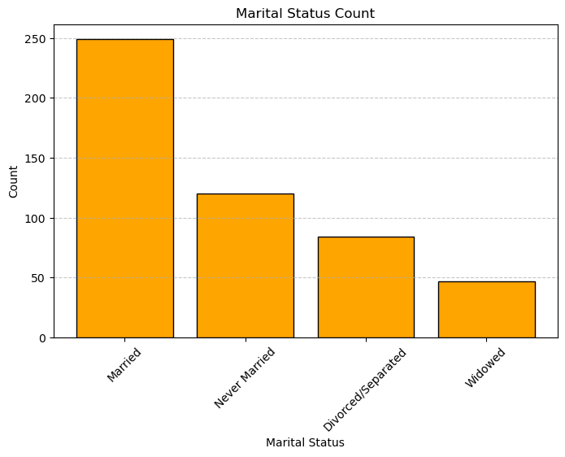

```python
marital_counts = data['marital_status'].value_counts()
plt.figure(figsize=(8, 5))
plt.bar(marital_counts.index, marital_counts.values, color='orange', edgecolor='black')
plt.title('Marital Status Count')
plt.xlabel('Marital Status')
plt.ylabel('Count')
plt.xticks(rotation=45)
plt.grid(axis='y', linestyle='--', alpha=0.7)
plt.show()
```

3. نمودار دایره‌ای (Pie Chart): نسبت وضعیت اشتغال (is_employed) درصد افراد شاغل و غیرشاغل به صورت نسبی نمایش داده شده است. اگر تعداد افراد شاغل بیشتر باشد، ممکن است نشان‌دهنده این باشد که داده‌ها به طور کلی شامل جمعیت کاری هستند. در مقابل، اگر افراد غیرشاغل بیشتر باشند، می‌تواند نمایانگر وضعیت اقتصادی یا ویژگی خاصی از داده‌ها باشد.

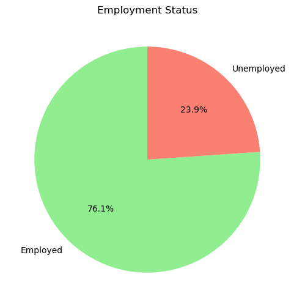

```python
employment_counts = data['is_employed'].value_counts()
plt.figure(figsize=(6, 6))
plt.pie(employment_counts, labels=['Employed', 'Unemployed'], autopct='%1.1f%%', colors=['lightgreen', 'salmon'], startangle=90)
plt.title('Employment Status')
plt.show()
```

4. پراکندگی (Scatter Plot): رابطه درآمد (income) و سن (age) نمودار نشان می‌دهد که آیا رابطه‌ای بین سن و درآمد وجود دارد یا خیر. مثلاً ممکن است افراد مسن‌تر درآمد بیشتری داشته باشند. اگر نقاط در امتداد یک خط قرار گیرند (مثلاً شیب مثبت)، نشان‌دهنده یک رابطه مثبت بین سن و درآمد است (افزایش سن = افزایش درآمد). اگر پراکندگی زیاد باشد، نشان می‌دهد که رابطه مشخصی بین این دو متغیر وجود ندارد و ممکن است عوامل دیگری تأثیرگذار باشند.

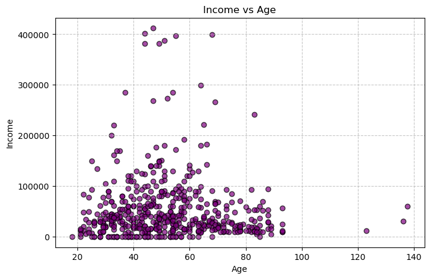

```python
plt.figure(figsize=(8, 5))
plt.scatter(data['age'], data['income'], alpha=0.7, color='purple', edgecolor='black')
plt.title('Income vs Age')
plt.xlabel('Age')
plt.ylabel('Income')
plt.grid(True, linestyle='--', alpha=0.7)
plt.show()
```

5. جعبه‌ای (Box Plot): توزیع درآمد (income) بر اساس جنسیت (sex) این نمودار نشان می‌دهد که توزیع درآمد برای مردان و زنان چگونه است. می‌توان میانه، چارک‌ها و پراکندگی داده‌ها را مشاهده کرد. گر میانه درآمد (خط وسط جعبه) برای یکی از جنسیت‌ها بالاتر باشد، نشان‌دهنده این است که به طور متوسط درآمد آن جنسیت بیشتر است. فاصله چارک‌ها (طول جعبه) نشان‌دهنده پراکندگی درآمد است. اگر پراکندگی در یکی از جنسیت‌ها بیشتر باشد، می‌تواند به این معنی باشد که در آن گروه تنوع درآمدی بیشتری وجود دارد. وجود نقاط پرت (outliers) نشان می‌دهد که برخی افراد درآمد بسیار بالاتر یا پایین‌تر از حد معمول دارند.

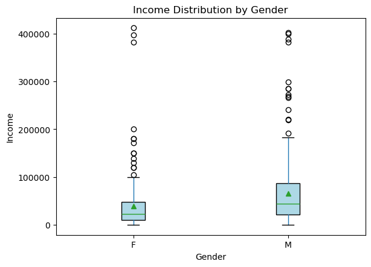

```python
plt.figure(figsize=(8, 5))
data.boxplot(column='income', by='sex', grid=False, showmeans=True, patch_artist=True, boxprops=dict(facecolor='lightblue'))
plt.title('Income Distribution by Gender')
plt.suptitle('')  # حذف عنوان اضافی
plt.xlabel('Gender')
plt.ylabel('Income')
plt.show()
```

موارد استفاده احتمالی این داده: تحلیل اقتصادی-اجتماعی: شناسایی الگوهای اشتغال، درآمد و مسکن. تحلیل منطقه‌ای: بررسی وضعیت اقتصادی یا دموگرافیک افراد در ایالت‌های مختلف. بازاریابی هدفمند: بر اساس درآمد و ویژگی‌های دموگرافیک، می‌توان تصمیم‌گیری‌های هدفمند انجام داد. سیاست‌گذاری: دولت‌ها می‌توانند بر اساس وضعیت مسکن، تأهل و درآمد، سیاست‌هایی برای رفاه اجتماعی تدوین کنند.